# In Silico Target Prediction with Consensus Scoring Revealed Previously Undiscovered Bioactivities of Dihydrochalcones

### *Fabian Mayr, Gabriele Möller, Ulrike Garscha, Patricia Rodríguez Castaño, Silvia Inderbinen, Birgit Waltenberger, Stefan Schwaiger, Stefan Martens, Alex Odermatt, Amit Pandey, Oliver Werz, Jerzy Adamski, Hermann Stuppner and Daniela Schuster*

This notebook contains the complete data treatment done in the manuscript, including all plots and i/o files.

```python
import pandas as pd
import matplotlib.pyplot as plt
import os
import numpy as np
from sklearn import preprocessing, metrics
import sys
sys.path.insert(0,'C:\\Users\\c7401370\\Documents\\pyvenn\\pyvenn-master\\pyvenn-master')
import venn
```

```python
path = 'B:\\Home\\Fabian Mayr\\Publication\\2019 Target Prediction DHCs\\inhouse predictions\\DHC_full_activity_profile_new'
os.chdir(path)

with open ('DHC_full_LS_mergedhitlists.csv','r') as f:
    LSdata = pd.read_csv(f,sep=';')
```

```python
LS = LSdata[['Name','Compound','Pharmacophore-Fit Score','Pharmacophore fit Score']]
LS.head()
```

|  | Name | Compound | Pharmacophore-Fit Score | Pharmacophore fit Score |
| --- | --- | --- | --- | --- |
| 0 | 17b-HSD3-LS3-1-317364-65-1-and-317364-71-9-mod... | 113900-91-7 | 36.35 | NaN |
| 1 | 17b-HSD3-LS3-1-317364-65-1-and-317364-71-9-mod... | 113866-89-0 | 36.35 | NaN |
| 2 | 17b-HSD3-LS3-1-317364-65-1-and-317364-71-9-mod... | 123134-05-4 | 36.35 | NaN |
| 3 | 17b-HSD3-LS3-1-317364-65-1-and-317364-71-9-mod... | 1379647-91-2 | 35.79 | NaN |
| 4 | 17b-HSD3-LS3-1-317364-65-1-and-317364-71-9-mod... | 1379647-92-3 | 35.09 | NaN |

LigandScout has introduced two different columns for the pharmacophore fit score, this has most likely happend due to the different LigandScout versions used. I will now create a new, single column named 'LS_score'.

```python
LS_scores = []
for index, row in LS.iterrows():
    if row['Pharmacophore-Fit Score'] > 0:
        LS_scores.append(row['Pharmacophore-Fit Score'])
    else:
        LS_scores.append(row['Pharmacophore fit Score'])
LS['LS_score'] = LS_scores
LS = LS[['Name','Compound','LS_score']]
LS.head()
```

|  | Name | Compound | LS_score |
| --- | --- | --- | --- |
| 0 | 17b-HSD3-LS3-1-317364-65-1-and-317364-71-9-mod... | 113900-91-7 | 36.35 |
| 1 | 17b-HSD3-LS3-1-317364-65-1-and-317364-71-9-mod... | 113866-89-0 | 36.35 |
| 2 | 17b-HSD3-LS3-1-317364-65-1-and-317364-71-9-mod... | 123134-05-4 | 36.35 |
| 3 | 17b-HSD3-LS3-1-317364-65-1-and-317364-71-9-mod... | 1379647-91-2 | 35.79 |
| 4 | 17b-HSD3-LS3-1-317364-65-1-and-317364-71-9-mod... | 1379647-92-3 | 35.09 |

Now, LS_score contains all of the pharmacophore-fit values. However, relative pharmacophore fit-values would be more appropriate, to not introduce bias caused by the amount of features. Thus, I load an excel-table that contains feature numbers, so that i can calculate relative pharmacophore fit-values in a new column called 'rel_score'. The formula to calculate relative pharmacophore fit-values from LigandScout pharmacophore fit-values is

\begin{align} rel. pharmacophore fit value = \frac{(pharmacophore fit value - 9)}{feature-no. * 10} \end{align}

```python
os.chdir('B:\\Models\\nach Programm')
with open ('ligandscout_models_features.csv','r') as f:
    LS_features = pd.read_csv(f,sep=';',names=['model','features'],index_col=0)
```

```python
LS = LS.join(LS_features, on='Name', how='left')
LS['rel_score'] = (LS['LS_score']-9)/(LS['features']*10)
LS = LS.drop(['LS_score','features'],axis=1)
LS.head()
```

|  | Name | Compound | rel_score |
| --- | --- | --- | --- |
| 0 | 17b-HSD3-LS3-1-317364-65-1-and-317364-71-9-mod... | 113900-91-7 | 0.911667 |
| 1 | 17b-HSD3-LS3-1-317364-65-1-and-317364-71-9-mod... | 113866-89-0 | 0.911667 |
| 2 | 17b-HSD3-LS3-1-317364-65-1-and-317364-71-9-mod... | 123134-05-4 | 0.911667 |
| 3 | 17b-HSD3-LS3-1-317364-65-1-and-317364-71-9-mod... | 1379647-91-2 | 0.893000 |
| 4 | 17b-HSD3-LS3-1-317364-65-1-and-317364-71-9-mod... | 1379647-92-3 | 0.869667 |

Now, lets start importing the results from the Discovery Studio models.

```python
path = 'B:\\Home\\Fabian Mayr\\Publication\\2019 Target Prediction DHCs\\inhouse predictions'
os.chdir(path)

with open ('DHC_full_ligandprofiler.csv','r') as f:
    DSdata = pd.read_csv(f)
DSdata.head()
```

|  | Structure | Index | Name | Visible | Tagged | Visibility Locked | Color | Calculate Charges | Number of Atoms | Molecular Formula | ... | PTP1b-1c87-opa-2.10-d-1 | PTP1b-1c88-ota-1.80-d-1 | PTP1b-1ecv-878-1.95-d-2 | PTP1b-1gfy-col-2.13-d-1 | PTP1b-2bgd-t1d-2.40-d-1 | PTP1b-2cnf-f32-2.20-d-1-s | PTP1b-2cnf-f32-2.20-d-1 | PTP1b-2cng-ize-1.90-d-1 | PTP1b-2cni-izf-2.00-d-1-s | PTP1b-2cni-izf-2.00-d-1 |
| --- | --- | --- | --- | --- | --- | --- | --- | --- | --- | --- | --- | --- | --- | --- | --- | --- | --- | --- | --- | --- | --- |
| 0 | NaN | 1 | (+) Linderatin | True | False | False | 255 255 255 255 | False | 59.0 | C25 H30 O4 | ... | 0.0 | 0.0 | 0.0 | 0.0 | 0.0 | 0.0 | 0.0 | 0.0 | 0.0 | 0.0 |
| 1 | NaN | 2 | (-) epi-Adunctin E | False | False | False | 255 255 255 255 | False | NaN | NaN | ... | 0.0 | 0.0 | 0.0 | 0.0 | 0.0 | 0.0 | 0.0 | 0.0 | 0.0 | 0.0 |
| 2 | NaN | 3 | (-) Linderatin | False | False | False | 255 255 255 255 | False | NaN | NaN | ... | 0.0 | 0.0 | 0.0 | 0.0 | 0.0 | 0.0 | 0.0 | 0.0 | 0.0 | 0.0 |
| 3 | NaN | 4 | (-) Methyllinderatin | False | False | False | 255 255 255 255 | False | NaN | NaN | ... | 0.0 | 0.0 | 0.0 | 0.0 | 0.0 | 0.0 | 0.0 | 0.0 | 0.0 | 0.0 |
| 4 | NaN | 5 | (-) Neolinderatin | False | False | False | 255 255 255 255 | False | NaN | NaN | ... | 0.0 | 0.0 | 0.0 | 0.0 | 0.0 | 0.0 | 0.0 | 0.0 | 0.0 | 0.0 |

5 rows × 163 columns

```python
DS = DSdata.drop(['Structure',
                  'Index',
             'Visible',
             'Tagged',
             'Visibility Locked',
             'Color',
             'Calculate Charges',
             'Number of Atoms',
            'Molecular Formula',
                  'Molecular Composition',
                 'Molecular Weight',
                 'Exact Mol. Weight',
                 'Net Formal Charge',
                 'AbsoluteEnergy',
                  'ConfNumber',
                  'RelativeEnergy'],
            axis=1)
DS.head()
```

|  | Name | 11b-HSD-1-refinedX005-1-HBA-model4new | 11b-HSD-triterpenes-common-features | 11b-HSD1-X005-1-HBA-ohneShape-model4 | 11b-HSD1-X005-1-model1 | 11b-HSD2-refinedX005-2-model2new | 17b-HSD3-DS-model-1-X007-1 | 17b-HSD3-DS-model-2-X007-31 | 17b-HSD4-quercetin-Wetzel-final | 17b-HSD4-Quercetin-Wetzel-HBA-F-model3-2 | ... | PTP1b-1c87-opa-2.10-d-1 | PTP1b-1c88-ota-1.80-d-1 | PTP1b-1ecv-878-1.95-d-2 | PTP1b-1gfy-col-2.13-d-1 | PTP1b-2bgd-t1d-2.40-d-1 | PTP1b-2cnf-f32-2.20-d-1-s | PTP1b-2cnf-f32-2.20-d-1 | PTP1b-2cng-ize-1.90-d-1 | PTP1b-2cni-izf-2.00-d-1-s | PTP1b-2cni-izf-2.00-d-1 |
| --- | --- | --- | --- | --- | --- | --- | --- | --- | --- | --- | --- | --- | --- | --- | --- | --- | --- | --- | --- | --- | --- |
| 0 | (+) Linderatin | 0.0 | 0.0 | 0.0 | 0.0 | 0.0 | 0.0 | 0.0 | 0.0 | 0.0 | ... | 0.0 | 0.0 | 0.0 | 0.0 | 0.0 | 0.0 | 0.0 | 0.0 | 0.0 | 0.0 |
| 1 | (-) epi-Adunctin E | 0.0 | 0.0 | 0.0 | 0.0 | 0.0 | 0.0 | 0.0 | 0.0 | 0.0 | ... | 0.0 | 0.0 | 0.0 | 0.0 | 0.0 | 0.0 | 0.0 | 0.0 | 0.0 | 0.0 |
| 2 | (-) Linderatin | 0.0 | 0.0 | 0.0 | 0.0 | 0.0 | 0.0 | 0.0 | 0.0 | 0.0 | ... | 0.0 | 0.0 | 0.0 | 0.0 | 0.0 | 0.0 | 0.0 | 0.0 | 0.0 | 0.0 |
| 3 | (-) Methyllinderatin | 0.0 | 0.0 | 0.0 | 0.0 | 0.0 | 0.0 | 0.0 | 0.0 | 0.0 | ... | 0.0 | 0.0 | 0.0 | 0.0 | 0.0 | 0.0 | 0.0 | 0.0 | 0.0 | 0.0 |
| 4 | (-) Neolinderatin | 0.0 | 0.0 | 0.0 | 0.0 | 0.0 | 0.0 | 0.0 | 0.0 | 0.0 | ... | 0.0 | 0.0 | 0.0 | 0.0 | 0.0 | 0.0 | 0.0 | 0.0 | 0.0 | 0.0 |

5 rows × 147 columns

```python
cols = list(DS.columns)
cols.pop(0)
DS = pd.melt(DS, id_vars=['Name'], var_name=['model'])
DS.columns = ['Compound','Name','rel_score']
DS = DS[DS['rel_score'] > 0.0]
DS.head()
```

|  | Compound | Name | rel_score |
| --- | --- | --- | --- |
| 11 | 113866-89-0 | 11b-HSD-1-refinedX005-1-HBA-model4new | 0.401274 |
| 12 | 113900-91-7 | 11b-HSD-1-refinedX005-1-HBA-model4new | 0.257744 |
| 13 | 116980-99-5 | 11b-HSD-1-refinedX005-1-HBA-model4new | 0.257277 |
| 19 | 1198475-52-3 | 11b-HSD-1-refinedX005-1-HBA-model4new | 0.360898 |
| 20 | 1198475-53-4 | 11b-HSD-1-refinedX005-1-HBA-model4new | 0.440080 |

Now, since both VS hitlists generated with LigandScout AND Discovery Studio pharmacophore models were prepared, they can be concatenated, followed by some small checks.

```python
data = pd.concat([LS,DS])
data.head()
```

|  | Compound | Name | rel_score |
| --- | --- | --- | --- |
| 0 | 113900-91-7 | 17b-HSD3-LS3-1-317364-65-1-and-317364-71-9-mod... | 0.911667 |
| 1 | 113866-89-0 | 17b-HSD3-LS3-1-317364-65-1-and-317364-71-9-mod... | 0.911667 |
| 2 | 123134-05-4 | 17b-HSD3-LS3-1-317364-65-1-and-317364-71-9-mod... | 0.911667 |
| 3 | 1379647-91-2 | 17b-HSD3-LS3-1-317364-65-1-and-317364-71-9-mod... | 0.893000 |
| 4 | 1379647-92-3 | 17b-HSD3-LS3-1-317364-65-1-and-317364-71-9-mod... | 0.869667 |

```python
LS.Name.count() + DS.Name.count() == data.Name.count()
```

```
True
```

```python
data.describe()
```

|  | rel_score |
| --- | --- |
| count | 9.601000e+03 |
| mean | 4.819061e-01 |
| std | 3.669742e-01 |
| min | 2.040410e-21 |
| 25% | 1.101460e-01 |
| 50% | 4.469430e-01 |
| 75% | 9.086220e-01 |
| max | 9.970000e-01 |

Everything seemed to have worked out right, and the rel_score column span is between 0 and 1, like its supposed to be!

```python
path = 'B:\\Home\\Fabian Mayr\\Publication\\2019 Target Prediction DHCs\\inhouse predictions'
os.chdir(path)

with open ('all_models.csv','r') as f:
    name_table = pd.read_csv(f,sep=';')

name_table = name_table[['model','UniProt']].set_index('model')
name_table.head()
```

| model | UniProt |
| --- | --- |
| model_DS4 | 3BHS1_HUMAN |
| Model_1 | 3BHS1_HUMAN |
| Model_2 | 3BHS1_HUMAN |
| AChE-1acj-tha-HBA-vers | ACES_HUMAN |
| AChE-1acj-tha-xvols | ACES_HUMAN |

```python
data1 = data.join(name_table, on='Name', how='left')
data1.head()
```

|  | Compound | Name | rel_score | UniProt |
| --- | --- | --- | --- | --- |
| 0 | 113900-91-7 | 17b-HSD3-LS3-1-317364-65-1-and-317364-71-9-mod... | 0.911667 | DHB3_HUMAN |
| 1 | 113866-89-0 | 17b-HSD3-LS3-1-317364-65-1-and-317364-71-9-mod... | 0.911667 | DHB3_HUMAN |
| 2 | 123134-05-4 | 17b-HSD3-LS3-1-317364-65-1-and-317364-71-9-mod... | 0.911667 | DHB3_HUMAN |
| 3 | 1379647-91-2 | 17b-HSD3-LS3-1-317364-65-1-and-317364-71-9-mod... | 0.893000 | DHB3_HUMAN |
| 4 | 1379647-92-3 | 17b-HSD3-LS3-1-317364-65-1-and-317364-71-9-mod... | 0.869667 | DHB3_HUMAN |

```python
data3 = data1.groupby(['Compound','UniProt']).mean().reset_index()
data3['platform'] = 'in-house models'
data3.rename(columns = {'UniProt':'UniProt_name'}, inplace = True)
data3.to_csv('DHC_full_inhouse.csv',sep=';')
data3.head()
```

|  | Compound | UniProt_name | rel_score | platform |
| --- | --- | --- | --- | --- |
| 0 | (+) Linderatin | ACES_HUMAN | 0.273489 | in-house models |
| 1 | (+) Linderatin | CP19A_HUMAN | 0.515082 | in-house models |
| 2 | (+) Linderatin | CP2D6_HUMAN | 0.446190 | in-house models |
| 3 | (+) Linderatin | DHI2_HUMAN | 0.722200 | in-house models |
| 4 | (+) Linderatin | GCR_HUMAN | 0.087805 | in-house models |

```python
len(data3['UniProt_name'].unique())
```

```
30
```

After cleaning and tidying the data, I will do some exploratory data analysis for the data generated only by the pharmacophore-based parallel VS. First, I will look at the frequencies: Which target's pharmacophore models mapped particularly often to compounds of the DHC_full dataset? For that, I will do a bar chart, and normalize the absolute numbers with the number of pharmacophore models that were used per target. This step is crucial, because some targets were modeled by several (e.g. ESR2_HUMAN by 28 pharmacophore models) and others just by very few models (e.g. CP19A_HUMAN by 3 pharmacophore models). So many matches don't necessarily mean good predictivity.

```python
name_table = name_table.reset_index().set_index('UniProt')
name_table_counts = name_table.groupby('UniProt').count()
name_table_counts = name_table_counts.rename(columns = {'model':'counts'})
```

```
Text(0,0.5,'count')
```

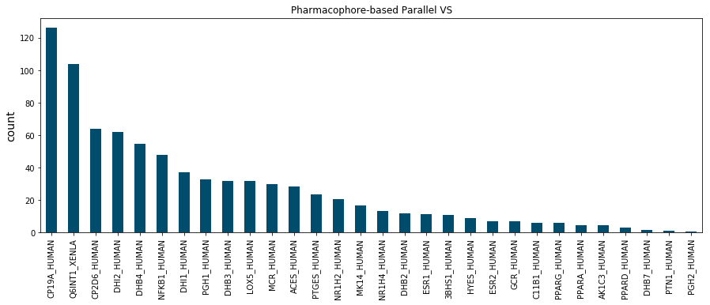

```python
stats = pd.DataFrame(data3['UniProt_name'].value_counts())
stats = stats.rename(columns = {'UniProt_name':'hits'})
stats = stats.join(name_table_counts)
stats['normalized_hits'] = stats.hits / stats.counts
stats = stats.sort_values(by=['normalized_hits'], ascending=False)
ax = stats['normalized_hits'].plot(kind='bar',figsize=(15, 5),color='#004c6d', title='Pharmacophore-based Parallel VS')
plt.figure(dpi=300)
ax.xaxis.set_label_coords(0.5,-0.35)
ax.set_ylabel('count', fontsize=14)
```

Now, lets import the target prediction results generated by our online tools, and perform the same analysis...

```python
path = 'B:\\Home\\Fabian Mayr\\Publication\\2019 Target Prediction DHCs\\TarPredCrawler\\final'
os.chdir(path)

with open ('DHC_full_online.csv','r') as f:
    online = pd.read_csv(f,sep=';')
online = online.rename(columns = {'prob':'rel_score','compound':'Compound'})
online.head()
```

|  | Compound | platform | rel_score | UniProt_name |
| --- | --- | --- | --- | --- |
| 0 | (+) Linderatin | SwissTargetPrediction | 0.165835531 | CATL1_HUMAN |
| 1 | (+) Linderatin | SwissTargetPrediction | 0.104440651 | LOX5_HUMAN |
| 2 | (+) Linderatin | SwissTargetPrediction | 0.104440651 | PTGES_HUMAN |
| 3 | (+) Linderatin | SEA | 5.22E-21 | PA2GA_RABIT |
| 4 | (+) Linderatin | SEA | 7.15E-18 | MDR1_HUMAN |

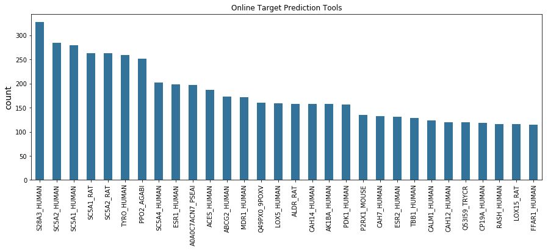

```python
onl = pd.DataFrame(online['UniProt_name'].value_counts())
onl.columns = ['count']
ax = onl.iloc[:30,:].plot(kind='bar',figsize=(15, 5),color='#33739a', title='Online Target Prediction Tools')
complete = plt.figure(dpi=300)
ax.xaxis.set_label_coords(0.5,-0.35)
ax.set_ylabel('count', fontsize=14)
ax.get_legend().remove()
```

Now its time to bring pharmacophore-based parallel VS results together with the online target prediction results:

```python
complete = pd.concat([data3,online])
complete['rel_score'] = pd.to_numeric(complete['rel_score'], errors='coerce')
complete['platform'] = complete['platform'].astype(str)
complete.head()
```

|  | Compound | UniProt_name | platform | rel_score |
| --- | --- | --- | --- | --- |
| 0 | (+) Linderatin | ACES_HUMAN | in-house models | 0.273489 |
| 1 | (+) Linderatin | CP19A_HUMAN | in-house models | 0.515082 |
| 2 | (+) Linderatin | CP2D6_HUMAN | in-house models | 0.446190 |
| 3 | (+) Linderatin | DHI2_HUMAN | in-house models | 0.722200 |
| 4 | (+) Linderatin | GCR_HUMAN | in-house models | 0.087805 |

An pivot it right away, to make the table mor tidy.

```python
path = 'B:\\Home\\Fabian Mayr\\Publication\\2019 Target Prediction DHCs'
os.chdir(path)

pivoted = pd.pivot_table(complete,
                    index=['Compound','UniProt_name'],
                    values='rel_score',
                    columns='platform',
                    fill_value=np.NaN).reset_index()
pivoted.to_csv('DHC_full_pivoted.csv',sep=';')
pivoted.head()
```

| platform | Compound | UniProt_name | SEA | SuperPred | SwissTargetPrediction | in-house models |
| --- | --- | --- | --- | --- | --- | --- |
| 0 | (+) Linderatin | ACES_HUMAN | NaN | NaN | NaN | 0.273489 |
| 1 | (+) Linderatin | B2LA1_HUMAN | 2.430000e-11 | NaN | NaN | NaN |
| 2 | (+) Linderatin | CATL1_HUMAN | NaN | NaN | 0.165836 | NaN |
| 3 | (+) Linderatin | COMT_RAT | 3.560000e-08 | NaN | NaN | NaN |
| 4 | (+) Linderatin | CP19A_HUMAN | NaN | NaN | NaN | 0.515082 |

```python
# add 'consensus' column (counter for consensus predictions) to table
pivoted['consensus'] = pivoted[['SEA','SuperPred','SwissTargetPrediction','in-house models']].count(axis='columns')
pivoted.head()
```

| platform | Compound | UniProt_name | SEA | SuperPred | SwissTargetPrediction | in-house models | consensus |
| --- | --- | --- | --- | --- | --- | --- | --- |
| 0 | (+) Linderatin | ACES_HUMAN | NaN | NaN | NaN | 0.273489 | 1 |
| 1 | (+) Linderatin | B2LA1_HUMAN | 2.430000e-11 | NaN | NaN | NaN | 1 |
| 2 | (+) Linderatin | CATL1_HUMAN | NaN | NaN | 0.165836 | NaN | 1 |
| 3 | (+) Linderatin | COMT_RAT | 3.560000e-08 | NaN | NaN | NaN | 1 |
| 4 | (+) Linderatin | CP19A_HUMAN | NaN | NaN | NaN | 0.515082 | 1 |

I have added a 'consensus' column with a simple count-function. This makes it easier to filter the table for top-ranked predictions. So first, lets look at the frequencies of predicted targets for the DHC_full dataset, after I filter the table for consensus = 3:

```
Text(0,0.5,'count')
```

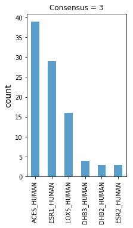

```python
# In-house hit AND consens with two online tools for targets
reduced_3 = pivoted[(pivoted['in-house models'].notnull()) & (pivoted['consensus'] == 3)]
ax = reduced_3['UniProt_name'].value_counts().plot(kind='bar',
                                              figsize=(3, 5),
                                              color='#5a9dc9',
                                              title='Consensus = 3')
plt.figure(dpi=500)
ax.xaxis.set_label_coords(0.5,-0.35)
ax.set_ylabel('count', fontsize=14)
```

... and let's do the same thing for consensus = 2:

```
Text(0,0.5,'count')
```

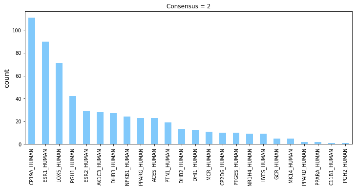

```python
# In-house hit AND consens with one online tools for targets
reduced_2 = pivoted[(pivoted['in-house models'].notnull()) & (pivoted['consensus'] == 2)]
ax = reduced_2['UniProt_name'].value_counts().plot(kind='bar',
                                              figsize=(12, 5),
                                              color='#81c9fb',
                                              title='Consensus = 2')
plt.figure(dpi=300)
ax.xaxis.set_label_coords(0.5,-0.35)
ax.set_ylabel('count', fontsize=14)
```

Now i want to count the instances that comply with the consensus = 3, consensus =2, etc. criteria

```python
print('consensus = 0: {} interactions'.format(pivoted[(pivoted['in-house models'].notnull())&
                                         (pivoted['consensus'] == 1)]['consensus'].count()))
print('consensus = 1: {} interactions'.format(pivoted[(pivoted['in-house models'].notnull())&
                                         (pivoted['consensus'] == 2)]['consensus'].count()))
print('consensus = 2: {} interactions'.format(pivoted[(pivoted['in-house models'].notnull())&
                                         (pivoted['consensus'] == 3)]['consensus'].count()))
print('consensus = 3: {} interactions'.format(pivoted[(pivoted['in-house models'].notnull())&
                                         (pivoted['consensus'] == 4)]['consensus'].count()))
```

```
consensus = 0: 4140 interactions
consensus = 1: 577 interactions
consensus = 2: 94 interactions
consensus = 3: 0 interactions
```

Here is a little experiment i did, but never really used in the end. Left it here though, as it may be of use to someone...

```python
# bring all probabilities to the same scale
normalized = pivoted.copy()
normalized['SEA'] = normalized['SEA'].apply(lambda x: x if (x == 0.0e0) else np.log10(x)*(-1))
normalized['SuperPred'] = normalized['SuperPred'].apply(lambda x: x if (x == 0.0e0) else np.log10(x)*(-1))
#df['Endocrine Disruptome'] = df['Endocrine Disruptome'].apply(lambda x: x if (x==0) else x*(-1))
normalized = normalized.fillna(0)

# normalize resulting probabilities
def normalizer(df, col):
    x = df[col].values.reshape(-1, 1)
    min_max_scaler = preprocessing.MinMaxScaler()
    X_train_minmax = min_max_scaler.fit_transform(x)
    return X_train_minmax
normalized['SEA'] = pd.DataFrame(normalizer(normalized,'SEA'))
normalized['SuperPred'] = pd.DataFrame(normalizer(normalized,'SuperPred'))
#df['Endocrine Disruptome'] = pd.DataFrame(normalizer(df,'Endocrine Disruptome'))
normalized.head()
```

| platform | Compound | UniProt_name | SEA | SuperPred | SwissTargetPrediction | in-house models | consensus |
| --- | --- | --- | --- | --- | --- | --- | --- |
| 0 | (+) Linderatin | ACES_HUMAN | 0.000000 | 0.324406 | 0.000000 | 0.273489 | 1 |
| 1 | (+) Linderatin | B2LA1_HUMAN | 0.052832 | 0.324406 | 0.000000 | 0.000000 | 1 |
| 2 | (+) Linderatin | CATL1_HUMAN | 0.000000 | 0.324406 | 0.165836 | 0.000000 | 1 |
| 3 | (+) Linderatin | COMT_RAT | 0.037074 | 0.324406 | 0.000000 | 0.000000 | 1 |
| 4 | (+) Linderatin | CP19A_HUMAN | 0.000000 | 0.324406 | 0.000000 | 0.515082 | 1 |

This was nice! But now its time to really have a look at the 10 compounds we can test afterwards. First, I filter the pivoted table for the compound-names I want, and save that to the variable 'tot'

```python
inhouse = data3[
    (data3['Compound'] == 'Phloretin') |
    (data3['Compound'] == '3-OH-phloretin') |
    (data3['Compound'] == 'Asebogenin') |
    (data3['Compound'] == 'Calomelanen') |
    (data3['Compound'] == '35241-55-5') |
    (data3['Compound'] == 'Phloretin xyloglucoside') |
    (data3['Compound'] == 'Sieboldin') |
    (data3['Compound'] == 'Trilobatin') |
    (data3['Compound'] == 'Neohesperidin dihydrochalcone') |
    (data3['Compound'] == 'Phloridzin')
]
```

```
Text(0,0.5,'count')
```

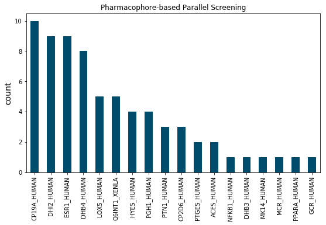

```python
ax = inhouse[inhouse['platform'] == 'in-house models']['UniProt_name'].value_counts().plot(kind='bar',
                                                 figsize=(9, 5),
                                                 color='#004c6d',
                                                 title='Pharmacophore-based Parallel Screening')
plt.figure(dpi=300)
ax.xaxis.set_label_coords(0.5,-0.35)
ax.set_ylabel('count', fontsize=14)
```

```python
tot = pivoted[
    (pivoted['Compound'] == 'Phloretin') |
    (pivoted['Compound'] == '3-OH-phloretin') |
    (pivoted['Compound'] == 'Asebogenin') |
    (pivoted['Compound'] == 'Calomelanen') |
    (pivoted['Compound'] == '35241-55-5') |
    (pivoted['Compound'] == 'Phloretin xyloglucoside') |
    (pivoted['Compound'] == 'Sieboldin') |
    (pivoted['Compound'] == 'Trilobatin') |
    (pivoted['Compound'] == 'Neohesperidin dihydrochalcone') |
    (pivoted['Compound'] == 'Phloridzin')
]
```

```python
path = 'B:\\Home\\Fabian Mayr\\Publication\\2019 Target Prediction DHCs'
os.chdir(path)

tot.to_csv('DHC_10_pivoted.csv',sep=';')
```

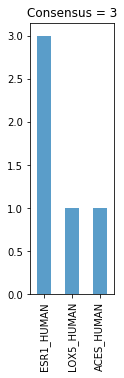

```python
tot[(tot['in-house models'].notnull()) & (tot['consensus'] == 3)]['UniProt_name'].value_counts().iloc[:18].plot(kind='bar',
                                                          figsize=(1.5, 5),
                                                          color='#5a9dc9',
                                                          title='Consensus = 3')
```

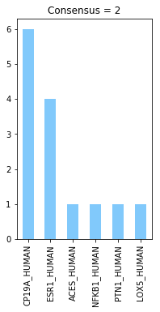

```python
tot[(tot['in-house models'].notnull()) & (tot['consensus'] == 2)]['UniProt_name'].value_counts().iloc[:18].plot(kind='bar',
                                                          figsize=(3, 5),
                                                          color='#81c9fb',
                                                          title='Consensus = 2')
```

Let's have alook at the number of interactions in the respective consensus categories look like:

```python
print('consensus = 0: {} interactions'.format(tot[(tot['in-house models'].notnull())&
                                         (tot['consensus'] == 1)]['consensus'].count()))
print('consensus = 1: {} interactions'.format(tot[(tot['in-house models'].notnull())&
                                         (tot['consensus'] == 2)]['consensus'].count()))
print('consensus = 2: {} interactions'.format(tot[(tot['in-house models'].notnull())&
                                         (tot['consensus'] == 3)]['consensus'].count()))
print('consensus = 3: {} interactions'.format(tot[(tot['in-house models'].notnull())&
                                         (tot['consensus'] == 4)]['consensus'].count()))
```

```
consensus = 0: 51 interactions
consensus = 1: 14 interactions
consensus = 2: 5 interactions
consensus = 3: 0 interactions
```

To get better viusality, I want to organize the different consensus categories in a venn-diagram. To do that, I first to bring back the unpivoted table containing all interactions. Next, I construct a new colun with a dummy-identifier, which is made up by concatenation of the compound name, | and the protein it is predicted as ligand for. Therby I get interactions that were predicted. Then, I can filter the table, e.g. for consensus = 3, write the concat-column to a list, and push that list into the venn diagram. The size of the intersections will be calculated automatically.

```python
compl = complete[
    (complete['Compound'] == 'Phloretin') |
    (complete['Compound'] == '3-OH-phloretin') |
    (complete['Compound'] == 'Asebogenin') |
    (complete['Compound'] == 'Calomelanen') |
    (complete['Compound'] == '35241-55-5') |
    (complete['Compound'] == 'Phloretin xyloglucoside') |
    (complete['Compound'] == 'Sieboldin') |
    (complete['Compound'] == 'Trilobatin') |
    (complete['Compound'] == 'Neohesperidin dihydrochalcone') |
    (complete['Compound'] == 'Phloridzin')
]
compl.head()
```

|  | Compound | UniProt_name | platform | rel_score |
| --- | --- | --- | --- | --- |
| 1776 | 3-OH-phloretin | CP19A_HUMAN | in-house models | 0.481996 |
| 1777 | 3-OH-phloretin | DHB4_HUMAN | in-house models | 0.383784 |
| 1778 | 3-OH-phloretin | DHI2_HUMAN | in-house models | 0.944500 |
| 1779 | 3-OH-phloretin | ESR1_HUMAN | in-house models | 0.946129 |
| 1780 | 3-OH-phloretin | PTN1_HUMAN | in-house models | 0.944600 |

```python
compl['concat'] = compl['Compound'].str.cat(compl['UniProt_name'],sep='|')
compl.head()
```

|  | Compound | UniProt_name | platform | rel_score | concat |
| --- | --- | --- | --- | --- | --- |
| 1776 | 3-OH-phloretin | CP19A_HUMAN | in-house models | 0.481996 | 3-OH-phloretin\|CP19A_HUMAN |
| 1777 | 3-OH-phloretin | DHB4_HUMAN | in-house models | 0.383784 | 3-OH-phloretin\|DHB4_HUMAN |
| 1778 | 3-OH-phloretin | DHI2_HUMAN | in-house models | 0.944500 | 3-OH-phloretin\|DHI2_HUMAN |
| 1779 | 3-OH-phloretin | ESR1_HUMAN | in-house models | 0.946129 | 3-OH-phloretin\|ESR1_HUMAN |
| 1780 | 3-OH-phloretin | PTN1_HUMAN | in-house models | 0.944600 | 3-OH-phloretin\|PTN1_HUMAN |

```python
house = compl[compl.platform == 'in-house models'].concat.values.tolist()
sea = compl[compl.platform == 'SEA'].concat.values.tolist()
stp = compl[compl.platform == 'SwissTargetPrediction'].concat.values.tolist()
sp = compl[compl.platform == 'SuperPred'].concat.values.tolist()
print(len(house),len(sea),len(stp),len(sp))
```

```
70 1183 244 3
```

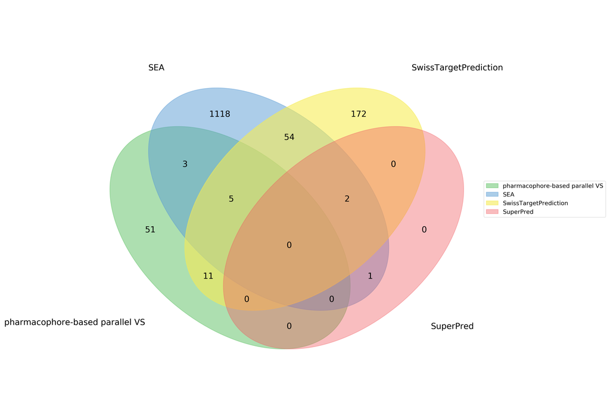

```python
labels = venn.get_labels([house,sea,stp,sp], fill=['number','logic'])
fig, ax = venn.venn4(labels,
                     names=['pharmacophore-based parallel VS','SEA','SwissTargetPrediction','SuperPred'],
                    dpi = 300)
```

For futher analyses, I rather need compound numbers instead of compound names. Therefore I import a csv table I constructed when I assembled DHC_full, since this table contains the original numbering as well.

More precisely, I want to append the top-scored predicted interactions to the network file of Figure 2, so that I can see a network with known interactions, and predicted interactions.

```python
### Map names with compound numbers for paper
path = 'B:\\Home\\Fabian Mayr\\Publication\\2019 Target Prediction DHCs\\Cytoscape file'
os.chdir(path)

with open ('DHC_compound.csv','r') as f:
    nums = pd.read_csv(f,sep=';',index_col='Name')

for_ntwrk = tot.join(nums, on=['Compound'], how='left')
for_ntwrk.head()
```

|  | Compound | UniProt_name | SEA | SuperPred | SwissTargetPrediction | in-house models | consensus | node_type | compound_no |
| --- | --- | --- | --- | --- | --- | --- | --- | --- | --- |
| 13557 | 3-OH-phloretin | A0A0C7ACN7_PSEAI | 8.540000e-28 | NaN | NaN | NaN | 1 | compound | 2 |
| 13558 | 3-OH-phloretin | AA2BR_RAT | 1.110000e-16 | NaN | NaN | NaN | 1 | compound | 2 |
| 13559 | 3-OH-phloretin | ACLY_RAT | 4.620000e-06 | NaN | NaN | NaN | 1 | compound | 2 |
| 13560 | 3-OH-phloretin | ADRB1_MOUSE | 2.360000e-13 | NaN | NaN | NaN | 1 | compound | 2 |
| 13561 | 3-OH-phloretin | AGRA_STAAU | 1.760000e-10 | NaN | NaN | NaN | 1 | compound | 2 |

```python
### Open mined Bioactivities
with open ('DHC_full_lit_network.csv','r') as f:
    lit = pd.read_csv(f,sep='|', index_col='Unnamed: 0')
lit.head()
```

|  | compound_name | type | uniprot_entry | edge_weight | protein_name | reactome_pathways | node_type | compound_no |
| --- | --- | --- | --- | --- | --- | --- | --- | --- |
| 0 | 1088-08-0 | literature | ANO1_HUMAN | 2 | Anoctamin-1 (Discovered on gastrointestinal st... | ['Stimuli-sensing channels'] | compound | 21 |
| 1 | 1088-08-0 | literature | FGF22_HUMAN | 1 | Fibroblast growth factor 22 (FGF-22) | ['PI3K Cascade', 'PIP3 activates AKT signaling... | compound | 21 |
| 2 | 1088-08-0 | literature | GNA15_HUMAN | 1 | Guanine nucleotide-binding protein subunit alp... | ['Acetylcholine regulates insulin secretion', ... | compound | 21 |
| 3 | 1088-08-0 | literature | KCNE1_HUMAN | 1 | Potassium voltage-gated channel subfamily E me... | ['Phase 3 - rapid repolarisation', 'Phase 2 - ... | compound | 21 |
| 4 | 1088-08-0 | literature | KCNQ1_HUMAN | 3 | Potassium voltage-gated channel subfamily KQT ... | ['Voltage gated Potassium channels', 'Phase 3 ... | compound | 21 |

Worked so far, I filter for consensus = 3 and conmsensus = 2. These are the predictions that shall be displayed in the network.

```python
### Filter dataframe for consensus hits selected with venn-diagram and save as official predictions
ntwrk = pd.concat([
    for_ntwrk[(for_ntwrk['in-house models'].notnull())&(for_ntwrk['consensus'] == 3)],
    for_ntwrk[(for_ntwrk['in-house models'].notnull())&(for_ntwrk['consensus'] == 2)],
])
ntwrk['type'] = 'predicted'
ntwrk = ntwrk[['Compound','consensus','type','UniProt_name','node_type','compound_no']]
ntwrk.columns = ['compound_name','edge_weight','type','uniprot_entry','node_type','compound_no']
ntwrk.head()
```

|  | compound_name | edge_weight | type | uniprot_entry | node_type | compound_no |
| --- | --- | --- | --- | --- | --- | --- |
| 20593 | Asebogenin | 3 | predicted | ESR1_HUMAN | compound | 4 |
| 21815 | Calomelanen | 3 | predicted | ACES_HUMAN | compound | 5 |
| 21903 | Calomelanen | 3 | predicted | ESR1_HUMAN | compound | 5 |
| 21958 | Calomelanen | 3 | predicted | LOX5_HUMAN | compound | 5 |
| 31773 | Phloretin | 3 | predicted | ESR1_HUMAN | compound | 1 |

```python
### Combine official predictions  with literature to one network
network = pd.concat([ntwrk,lit])
network['name_short'] = network['uniprot_entry'].apply(lambda x: x[:-6])
network.to_csv('DHC_10_network.csv',sep=';',index=False)
network.head()
```

|  | compound_name | compound_no | edge_weight | node_type | protein_name | reactome_pathways | type | uniprot_entry | name_short |
| --- | --- | --- | --- | --- | --- | --- | --- | --- | --- |
| 20593 | Asebogenin | 4 | 3 | compound | NaN | NaN | predicted | ESR1_HUMAN | ESR1 |
| 21815 | Calomelanen | 5 | 3 | compound | NaN | NaN | predicted | ACES_HUMAN | ACES |
| 21903 | Calomelanen | 5 | 3 | compound | NaN | NaN | predicted | ESR1_HUMAN | ESR1 |
| 21958 | Calomelanen | 5 | 3 | compound | NaN | NaN | predicted | LOX5_HUMAN | LOX5 |
| 31773 | Phloretin | 1 | 3 | compound | NaN | NaN | predicted | ESR1_HUMAN | ESR1 |

Now, that I have my predictions, and selected 6 proteins as potential targets for *in-vitro* testing, I want to plot 2 heatmaps: One *in-silico* activity profile, and one *in-vitro* activity profile. Also, I want six bar charts for plotting the activity data of the proteins.

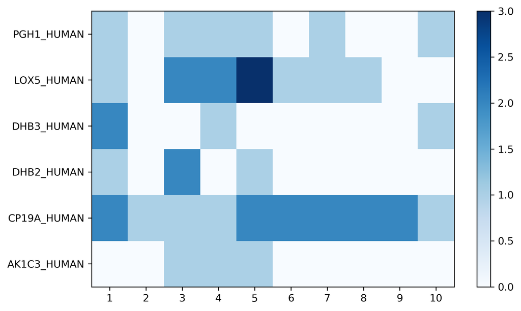

```python
h = tot[(tot['UniProt_name'] == 'LOX5_HUMAN')|
        (tot['UniProt_name'] == 'CP19A_HUMAN')|
        (tot['UniProt_name'] == 'DHB3_HUMAN')|
        (tot['UniProt_name'] == 'DHB2_HUMAN')|
        (tot['UniProt_name'] == 'PGH1_HUMAN')|
        (tot['UniProt_name'] == 'AK1C3_HUMAN')]

heat = h[['Compound','UniProt_name','consensus']]
heatmap = pd.pivot_table(heat,index='UniProt_name',
                    values='consensus',
                    columns='Compound',
                    fill_value=0)

heatmap.columns = [2,3,4,5,10,1,9,7,6,8]
heatmap = heatmap[[1,2,3,4,5,6,7,8,9,10]].sort_index()
plt.figure(figsize=(8,5),dpi=300)
ax = plt.pcolor(heatmap,cmap='Blues')
plt.yticks(np.arange(0.5, len(heatmap.index), 1),heatmap.index,fontsize=10)
plt.xticks(np.arange(0.5, len(heatmap.columns), 1),heatmap.columns,fontsize=10)
plt.colorbar(ax)
```

```python
path = 'B:\\Home\\Fabian Mayr\\Publication\\2019 Target Prediction DHCs\\measured activities'
os.chdir(path)

with open ('activities.csv','r') as f:
    activities = pd.read_csv(f,sep=';',nrows=12)
per_inh = activities.iloc[1:,[0,1,2,4,6,8,10,12]]
per_inh.columns = ['Compound','Compound_no','DHB3_HUMAN','AK1C3_HUMAN','DHB2_HUMAN','LOX5_HUMAN','PGH1_HUMAN','CP19A_HUMAN']
per_inh[['PGH1_HUMAN','LOX5_HUMAN','DHB3_HUMAN','DHB2_HUMAN','CP19A_HUMAN','AK1C3_HUMAN']]
per_inh = per_inh.sort_values(by='Compound_no').reset_index()
perc_inh = per_inh.iloc[:,2:].apply(pd.to_numeric)
perc_inh['Compound_no'] = perc_inh['Compound_no'].astype(int)
#perc_inh.iloc[10,0] = 'positive control'
perc_inh
```

|  | Compound_no | DHB3_HUMAN | AK1C3_HUMAN | DHB2_HUMAN | LOX5_HUMAN | PGH1_HUMAN | CP19A_HUMAN |
| --- | --- | --- | --- | --- | --- | --- | --- |
| 0 | 1 | 1.7 | 24.8 | -50.7 | 85.38 | 43.46 | 13.75 |
| 1 | 2 | 43.8 | 15.5 | -14.1 | 99.15 | 48.07 | 21.06 |
| 2 | 3 | -28.0 | 13.8 | -26.3 | 54.12 | 53.94 | -1.00 |
| 3 | 4 | 52.7 | 34.4 | -31.2 | 39.15 | 24.39 | 3.51 |
| 4 | 5 | 32.1 | 35.2 | -17.6 | 47.16 | 49.54 | 17.00 |
| 5 | 6 | 16.7 | -6.1 | -39.0 | 34.77 | 12.34 | 13.75 |
| 6 | 7 | 20.2 | -7.2 | -40.5 | 40.75 | -4.16 | 9.36 |
| 7 | 8 | -0.6 | 5.3 | -49.8 | 45.46 | 15.30 | 5.85 |
| 8 | 9 | 45.8 | -1.3 | -37.1 | 31.81 | -11.40 | 0.67 |
| 9 | 10 | 37.5 | 7.4 | -32.2 | 7.72 | 11.07 | 0.00 |
| 10 | 11 | 101.2 | 90.5 | 76.1 | 79.26 | 81.29 | 70.18 |

```python
stdev_inh = activities.iloc[1:,[1,3,5,7,9,11,13]]
stdev_inh.columns = ['Compound_no','DHB3_HUMAN','AK1C3_HUMAN','DHB2_HUMAN','LOX5_HUMAN','PGH1_HUMAN','CP19A_HUMAN']
stdev_inh = stdev_inh.apply(pd.to_numeric)
stdev_inh['Compound_no'] = stdev_inh['Compound_no'].astype(int)
stdevs = stdev_inh.set_index('Compound_no').sort_index()
#stdevs = stdevs.set_index(perc_inh.Compound_no)
stdevs
```

| Compound_no | DHB3_HUMAN | AK1C3_HUMAN | DHB2_HUMAN | LOX5_HUMAN | PGH1_HUMAN | CP19A_HUMAN |
| --- | --- | --- | --- | --- | --- | --- |
| 1 | 4.5 | 5.9 | 22.7 | 9.34 | 7.17 | 2.00 |
| 2 | 4.7 | 4.9 | 27.1 | 1.20 | 12.01 | 11.69 |
| 3 | 20.5 | 10.0 | 28.8 | 11.56 | 5.31 | 12.00 |
| 4 | 49.6 | 5.1 | 8.1 | 11.05 | 4.18 | 19.00 |
| 5 | 27.2 | 3.8 | 39.0 | 24.23 | 1.92 | 2.00 |
| 6 | 14.5 | 6.8 | 29.9 | 14.17 | 29.00 | 4.38 |
| 7 | 17.7 | 8.9 | 22.9 | 4.05 | 45.60 | 3.50 |
| 8 | 10.0 | 11.5 | 21.4 | 2.73 | 26.35 | 3.50 |
| 9 | 14.2 | 1.9 | 44.3 | 29.42 | 15.06 | 4.00 |
| 10 | 23.9 | 11.8 | 15.4 | 6.03 | 13.23 | 5.84 |
| 11 | 2.4 | 1.2 | 11.4 | 5.95 | 7.47 | 0.50 |

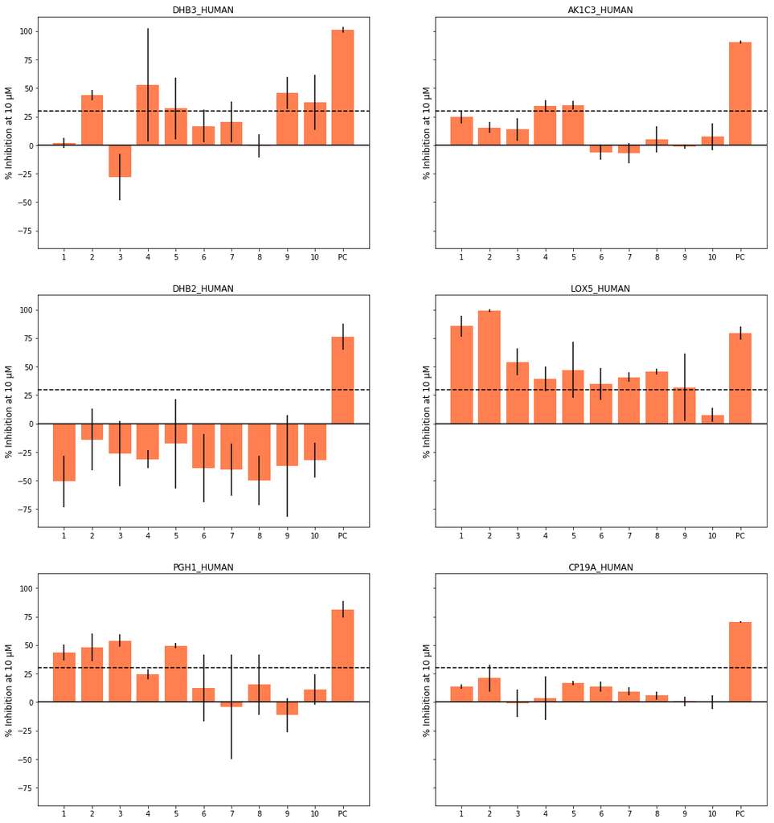

```python
def plot_activities(df,x,y,x_ax,y_ax,cutoff):
    axes[x][y].bar(df[x_ax],df[y_ax],yerr=stdevs[y_ax],color='coral') #
    axes[x][y].axhline(cutoff,linestyle='--',color='k') # cutoff dashed-line
    axes[x][y].axhline(0,color='k') # 0-line
    axes[x][y].title.set_text(y_ax) # set title
    axes[x][y].set_ylabel('% Inhibition at 10 µM',fontsize=12) # set y-axis label
    plt.setp(axes,
             xticks=range(1,12),
             xticklabels=[1,2,3,4,5,6,7,8,9,10,'PC'],
             visible=True)

x = 3
y = 2

fig, axes = plt.subplots(x,y,sharey=True,figsize=(x*6,y*10))
plt.figure(dpi=300)

k = 0
targets = perc_inh.columns.tolist()[1:]
for i in range(0,x):
    for j in range(0,y):
        plot_activities(perc_inh,i,j,'Compound_no',targets[k],30)
        k+=1
```

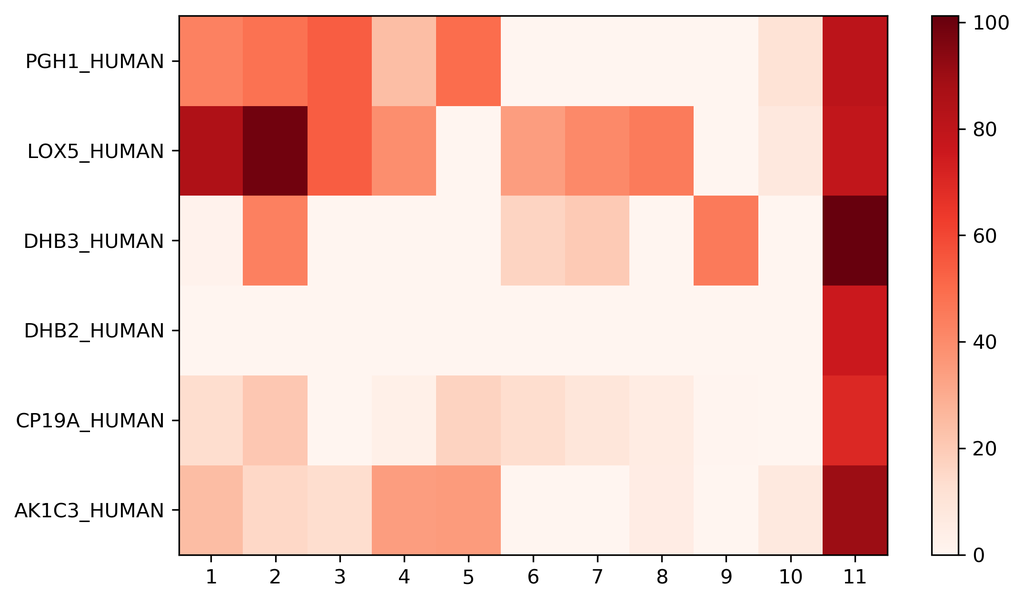

```python
hot = perc_inh.set_index('Compound_no').transpose().sort_index()
hot[hot < 0] = 0 # set all negative inhibition values to '0'
std = stdevs.transpose().sort_index()
hot[std > 19.99] = 0 # set all large standard deviations to '0'
plt.figure(figsize=(8,5),dpi=300)
ax = plt.pcolor(hot,cmap='Reds')
plt.yticks(np.arange(0.5, len(hot.index), 1),hot.index,fontsize=10)
plt.xticks(np.arange(0.5, len(hot.columns), 1),hot.columns,fontsize=10)
plt.colorbar(ax)
```

```python
sp = activities.iloc[1:,[0,1,14,16,18,20,22,24]]
sp = sp.rename({'Unnamed: 0':'Compound','Unnamed: 1':'Compound_no'},axis=1)
sp['Compound_no'] = sp['Compound_no'].astype(int)
sp.iloc[:,2:] = sp.iloc[:,2:].apply(pd.to_numeric)
sp = sp.sort_values(by='Compound_no')
sp
```

|  | Compound | Compound_no | DHB4_HUMAN | DHI1_HUMAN | DHI2_HUMAN | CP17A_HUMAN | 3BHS2_HUMAN | HYES_HUMAN |
| --- | --- | --- | --- | --- | --- | --- | --- | --- |
| 7 | phloretin | 1 | 11.8 | 0.00 | 0.00 | 13.75 | 13.75 | 12.11 |
| 1 | 3-OH-phloretin | 2 | 30.4 | 0.59 | -7.83 | 21.06 | 21.06 | 16.13 |
| 2 | 35241-55-5 | 3 | 24.0 | 7.89 | -7.32 | -1.00 | -1.00 | 5.67 |
| 3 | asebogenin | 4 | 22.7 | 14.30 | 14.17 | 3.51 | 3.51 | 21.54 |
| 4 | calomelanen | 5 | 23.1 | 10.13 | 33.46 | 17.00 | 17.00 | 0.32 |
| 9 | sieboldin | 6 | 11.7 | 4.61 | -8.34 | 13.75 | 13.75 | -5.78 |
| 8 | phloridzin | 7 | 7.6 | 0.00 | 0.00 | 9.36 | 9.36 | -4.00 |
| 10 | trilobatin | 8 | 13.5 | -3.03 | -3.86 | 5.85 | 5.85 | -3.67 |
| 6 | phloretin xyloglucoside | 9 | 17.8 | 5.87 | -7.27 | 0.67 | 0.67 | -5.07 |
| 5 | neohesperidin DHC | 10 | 18.9 | 10.61 | 3.84 | 0.00 | 0.00 | -6.47 |
| 11 | pos control | 11 | 35.1 | 103.68 | 93.06 | 70.18 | 70.18 | 88.11 |

```python
se = activities.iloc[1:,[0,1,15,17,19,21,23,25]]
se = se.rename({'Unnamed: 0':'Compound','Unnamed: 1':'Compound_no'},axis=1)
se.columns = sp.columns
se['Compound_no'] = se['Compound_no'].astype(int)
se.iloc[:,2:] = se.iloc[:,2:].apply(pd.to_numeric)
se = se.sort_values(by='Compound_no')
se
```

|  | Compound | Compound_no | DHB4_HUMAN | DHI1_HUMAN | DHI2_HUMAN | CP17A_HUMAN | 3BHS2_HUMAN | HYES_HUMAN |
| --- | --- | --- | --- | --- | --- | --- | --- | --- |
| 7 | phloretin | 1 | 8.3 | 0.00 | 0.00 | 2.00 | 2.00 | 0.00 |
| 1 | 3-OH-phloretin | 2 | 6.1 | 1.39 | 9.01 | 11.69 | 11.69 | 9.01 |
| 2 | 35241-55-5 | 3 | 3.9 | 1.67 | 7.24 | 12.00 | 12.00 | 7.24 |
| 3 | asebogenin | 4 | 12.3 | 3.66 | 2.53 | 19.00 | 19.00 | 2.53 |
| 4 | calomelanen | 5 | 13.4 | 3.51 | 16.42 | 2.00 | 2.00 | 16.42 |
| 9 | sieboldin | 6 | 5.5 | 8.15 | 6.81 | 4.38 | 4.38 | 6.81 |
| 8 | phloridzin | 7 | 6.0 | 0.00 | 0.00 | 3.50 | 3.50 | 0.00 |
| 10 | trilobatin | 8 | 9.0 | 6.34 | 10.27 | 3.50 | 3.50 | 10.27 |
| 6 | phloretin xyloglucoside | 9 | 13.5 | 8.11 | 2.02 | 4.00 | 4.00 | 2.02 |
| 5 | neohesperidin DHC | 10 | 6.9 | 9.77 | 25.52 | 5.84 | 5.84 | 25.52 |
| 11 | pos control | 11 | 3.5 | 1.08 | 3.51 | 0.50 | 0.50 | 2.37 |

We also did some other assays with the 10 DHCs, mostly because we had them at hand even if the predictions were not so good. These plots will go into the Supporting Informations. I plotted those as well here:

```python
def plot_supp_info(target,values,errors,cutoff,dpi):
    fig,ax = plt.subplots()
    fig.set_size_inches(6.49, 4)
    ax.bar(values.Compound_no,values[target],color='coral',yerr=errors[target]) # plot bar chart
    ax.axhline(cutoff,linestyle='--',color='k') # cutoff dashed-line
    ax.axhline(0,color='k') # 0-line
    ax.set_title(target) # set title
    ax.set_ylabel('% Inhibition at 10 µM',fontsize=12) # set y-axis label
    ax.set_ylim(-75,120) # set y-axis range
    ax.set_xticks(values.Compound_no)
    ax.set_xticklabels([1,2,3,4,5,6,7,8,9,10,'PC'], fontsize = 12)
    plt.savefig('{}.png'.format(target),dpi=dpi)
```

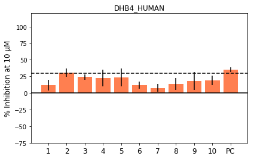

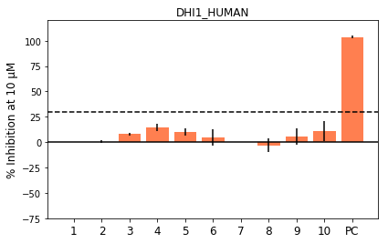

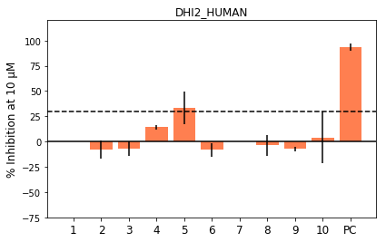

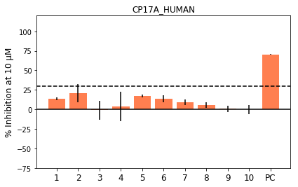

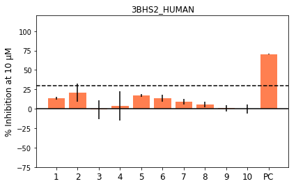

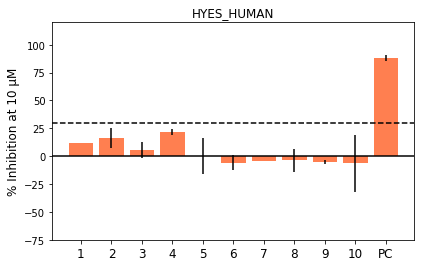

```python
path = 'B:\\Home\\Fabian Mayr\\Publication\\2019 Target Prediction DHCs\\Figures\\Suppurting Information\\Assay plots'
os.chdir(path)

trgts = sp.columns[2:]
for target in trgts:
    plot_supp_info(target,sp,se,30,300)
```

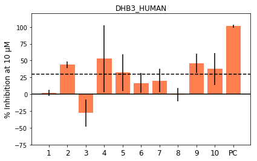

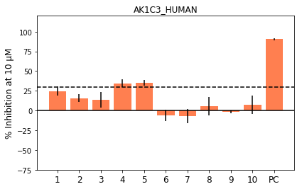

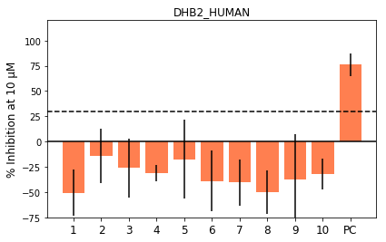

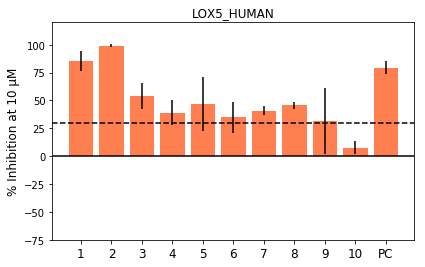

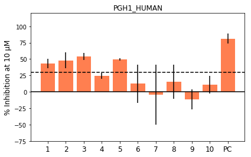

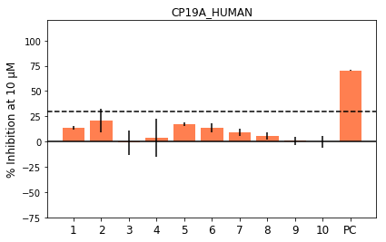

```python
path = 'B:\\Home\\Fabian Mayr\\Publication\\2019 Target Prediction DHCs\\Figures\\Graphical abstarct'
os.chdir(path)

trgts = perc_inh.columns[1:]
for target in trgts:
    plot_supp_info(target,perc_inh,stdevs,30,300)
```

One last task: Calculating some metrics. I did this based on the scikit-learn library, but it was still a mess: Too many variables and nesting of at least 3 for loops needed... Finally I decided to hard code.

```python
x = perc_inh.set_index('Compound_no').iloc[:10,:]
x
```

| Compound_no | DHB3_HUMAN | AK1C3_HUMAN | DHB2_HUMAN | LOX5_HUMAN | PGH1_HUMAN | CP19A_HUMAN |
| --- | --- | --- | --- | --- | --- | --- |
| 1 | 1.7 | 24.8 | -50.7 | 85.38 | 43.46 | 13.75 |
| 2 | 43.8 | 15.5 | -14.1 | 99.15 | 48.07 | 21.06 |
| 3 | -28.0 | 13.8 | -26.3 | 54.12 | 53.94 | -1.00 |
| 4 | 52.7 | 34.4 | -31.2 | 39.15 | 24.39 | 3.51 |
| 5 | 32.1 | 35.2 | -17.6 | 47.16 | 49.54 | 17.00 |
| 6 | 16.7 | -6.1 | -39.0 | 34.77 | 12.34 | 13.75 |
| 7 | 20.2 | -7.2 | -40.5 | 40.75 | -4.16 | 9.36 |
| 8 | -0.6 | 5.3 | -49.8 | 45.46 | 15.30 | 5.85 |
| 9 | 45.8 | -1.3 | -37.1 | 31.81 | -11.40 | 0.67 |
| 10 | 37.5 | 7.4 | -32.2 | 7.72 | 11.07 | 0.00 |

```python
y = stdevs.iloc[:10,:]
y
```

| Compound_no | DHB3_HUMAN | AK1C3_HUMAN | DHB2_HUMAN | LOX5_HUMAN | PGH1_HUMAN | CP19A_HUMAN |
| --- | --- | --- | --- | --- | --- | --- |
| 1 | 4.5 | 5.9 | 22.7 | 9.34 | 7.17 | 2.00 |
| 2 | 4.7 | 4.9 | 27.1 | 1.20 | 12.01 | 11.69 |
| 3 | 20.5 | 10.0 | 28.8 | 11.56 | 5.31 | 12.00 |
| 4 | 49.6 | 5.1 | 8.1 | 11.05 | 4.18 | 19.00 |
| 5 | 27.2 | 3.8 | 39.0 | 24.23 | 1.92 | 2.00 |
| 6 | 14.5 | 6.8 | 29.9 | 14.17 | 29.00 | 4.38 |
| 7 | 17.7 | 8.9 | 22.9 | 4.05 | 45.60 | 3.50 |
| 8 | 10.0 | 11.5 | 21.4 | 2.73 | 26.35 | 3.50 |
| 9 | 14.2 | 1.9 | 44.3 | 29.42 | 15.06 | 4.00 |
| 10 | 23.9 | 11.8 | 15.4 | 6.03 | 13.23 | 5.84 |

```python
z = heatmap.transpose()[x.columns]
z = z > 0
z
```

| UniProt_name | DHB3_HUMAN | AK1C3_HUMAN | DHB2_HUMAN | LOX5_HUMAN | PGH1_HUMAN | CP19A_HUMAN |
| --- | --- | --- | --- | --- | --- | --- |
| 1 | True | False | True | True | True | True |
| 2 | False | False | False | False | False | True |
| 3 | False | True | True | True | True | True |
| 4 | True | True | False | True | True | True |
| 5 | False | True | True | True | True | True |
| 6 | False | False | False | True | False | True |
| 7 | False | False | False | True | True | True |
| 8 | False | False | False | True | False | True |
| 9 | False | False | False | False | False | True |
| 10 | True | False | False | False | True | True |

```python
xy = (x >= 30.0) & (y < 20.0)
xy
```

| Compound_no | DHB3_HUMAN | AK1C3_HUMAN | DHB2_HUMAN | LOX5_HUMAN | PGH1_HUMAN | CP19A_HUMAN |
| --- | --- | --- | --- | --- | --- | --- |
| 1 | False | False | False | True | True | False |
| 2 | True | False | False | True | True | False |
| 3 | False | False | False | True | True | False |
| 4 | False | True | False | True | False | False |
| 5 | False | True | False | False | True | False |
| 6 | False | False | False | True | False | False |
| 7 | False | False | False | True | False | False |
| 8 | False | False | False | True | False | False |
| 9 | True | False | False | False | False | False |
| 10 | False | False | False | False | False | False |

```python
def get_metrics(target,subset_pred,subset_true):
    if subset_true[target].sum() > 0:
        tn, fp, fn, tp = metrics.confusion_matrix(subset_true[target],subset_pred[target]).ravel()
        acc = metrics.accuracy_score(subset_true[target],subset_pred[target])
        rec = metrics.recall_score(subset_true[target],subset_pred[target])
        pre = metrics.precision_score(subset_true[target],subset_pred[target])
        EF = pre / ((tp + fn) / (tn + fp))
        max_EF = (1 / ((tp + fn) / (tn + fp)))
        rel_EF = EF/max_EF
    else:
        acc = 0.0
        rec = 0.0
        pre = 0.0
        EF = 0.0
        max_EF = 0.0
        rel_EF = 0.0
    return acc, rec, pre, rel_EF

cons_metr = pd.DataFrame(index = ['accuracy', 'recall', 'precision', 'rel_EF'])
for i in x.columns:
    acc, rec, pre, rel_EF = get_metrics(i,z,xy)
    cons_metr[i] = [acc, rec, pre, rel_EF]

cons_metr
```

|  | DHB3_HUMAN | AK1C3_HUMAN | DHB2_HUMAN | LOX5_HUMAN | PGH1_HUMAN | CP19A_HUMAN |
| --- | --- | --- | --- | --- | --- | --- |
| accuracy | 0.5 | 0.900000 | 0.0 | 0.800000 | 0.60 | 0.0 |
| recall | 0.0 | 1.000000 | 0.0 | 0.857143 | 0.75 | 0.0 |
| precision | 0.0 | 0.666667 | 0.0 | 0.857143 | 0.50 | 0.0 |
| rel_EF | 0.0 | 0.666667 | 0.0 | 0.857143 | 0.50 | 0.0 |

```python
for_metrics = tot[(tot['UniProt_name'] == 'LOX5_HUMAN')|
          (tot['UniProt_name'] == 'CP19A_HUMAN')|
          (tot['UniProt_name'] == 'DHB2_HUMAN')|
          (tot['UniProt_name'] == 'DHB3_HUMAN')|
          (tot['UniProt_name'] == 'PGH1_HUMAN')|
          (tot['UniProt_name'] == 'AK1C3_HUMAN')]
```

```python
knoz = for_metrics[for_metrics['in-house models'].notnull()].join(nums, on='Compound', how='left')
knozzz = pd.pivot_table(knoz,
                    index='compound_no',
                    values='in-house models',
                    columns='UniProt_name')

missing_ind = []
for i in xy.index:
    if i not in knozzz.index:
        missing_ind.append(i)
frame = pd.concat([knozzz,pd.DataFrame(index=missing_ind,columns=knozzz.columns)])

missing_cols = []
for i in xy.columns:
    if i not in knozzz.columns:
        missing_cols.append(i)
inhouse = pd.concat([frame,pd.DataFrame(index=frame.index,columns=missing_cols)],axis=1)
inhouse = inhouse.notnull().sort_index()

inhouse_metr = pd.DataFrame(index = ['accuracy', 'recall', 'precision', 'rel_EF'])
for i in inhouse.columns:
    acc, rec, pre, rel_EF = get_metrics(i,inhouse,xy)
    inhouse_metr[i] = [acc, rec, pre, rel_EF]

inhouse_metr
```

|  | CP19A_HUMAN | DHB3_HUMAN | LOX5_HUMAN | PGH1_HUMAN | AK1C3_HUMAN | DHB2_HUMAN |
| --- | --- | --- | --- | --- | --- | --- |
| accuracy | 0.0 | 0.7 | 0.600000 | 0.6 | 0.8 | 0.0 |
| recall | 0.0 | 0.0 | 0.571429 | 0.5 | 0.0 | 0.0 |
| precision | 0.0 | 0.0 | 0.800000 | 0.5 | 0.0 | 0.0 |
| rel_EF | 0.0 | 0.0 | 0.800000 | 0.5 | 0.0 | 0.0 |

```python
knoz = for_metrics[for_metrics['SEA'].notnull()].join(nums, on='Compound', how='left')
knozzz = pd.pivot_table(knoz,
                    index='compound_no',
                    values='SEA',
                    columns='UniProt_name')

missing_ind = []
for i in xy.index:
    if i not in knozzz.index:
        missing_ind.append(i)
frame = pd.concat([knozzz,pd.DataFrame(index=missing_ind,columns=knozzz.columns)])

missing_cols = []
for i in xy.columns:
    if i not in knozzz.columns:
        missing_cols.append(i)
sea = pd.concat([frame,pd.DataFrame(index=frame.index,columns=missing_cols)],axis=1)
sea = sea.notnull().sort_index()

sea_metr = pd.DataFrame(index = ['accuracy', 'recall', 'precision', 'rel_EF'])
for i in sea.columns:
    acc, rec, pre, rel_EF = get_metrics(i,sea,xy)
    sea_metr[i] = [acc, rec, pre, rel_EF]

sea_metr
```

|  | AK1C3_HUMAN | DHB2_HUMAN | DHB3_HUMAN | LOX5_HUMAN | PGH1_HUMAN | CP19A_HUMAN |
| --- | --- | --- | --- | --- | --- | --- |
| accuracy | 0.900000 | 0.0 | 0.6 | 0.400000 | 0.6 | 0.0 |
| recall | 1.000000 | 0.0 | 0.0 | 0.285714 | 0.0 | 0.0 |
| precision | 0.666667 | 0.0 | 0.0 | 0.666667 | 0.0 | 0.0 |
| rel_EF | 0.666667 | 0.0 | 0.0 | 0.666667 | 0.0 | 0.0 |

```python
knoz = for_metrics[for_metrics['SwissTargetPrediction'].notnull()].join(nums, on='Compound', how='left')
knozzz = pd.pivot_table(knoz,
                    index='compound_no',
                    values='SwissTargetPrediction',
                    columns='UniProt_name')

missing_ind = []
for i in xy.index:
    if i not in knozzz.index:
        missing_ind.append(i)
frame = pd.concat([knozzz,pd.DataFrame(index=missing_ind,columns=knozzz.columns)])

missing_cols = []
for i in xy.columns:
    if i not in knozzz.columns:
        missing_cols.append(i)
stp = pd.concat([frame,pd.DataFrame(index=frame.index,columns=missing_cols)],axis=1)
stp = stp.notnull().sort_index()

stp_metr = pd.DataFrame(index = ['accuracy', 'recall', 'precision', 'rel_EF'])
for i in stp.columns:
    acc, rec, pre, rel_EF = get_metrics(i,stp,xy)
    stp_metr[i] = [acc, rec, pre, rel_EF]

stp_metr
```

|  | CP19A_HUMAN | DHB2_HUMAN | DHB3_HUMAN | LOX5_HUMAN | PGH1_HUMAN | AK1C3_HUMAN |
| --- | --- | --- | --- | --- | --- | --- |
| accuracy | 0.0 | 0.0 | 0.7 | 0.400000 | 0.60 | 0.8 |
| recall | 0.0 | 0.0 | 0.0 | 0.285714 | 0.25 | 0.0 |
| precision | 0.0 | 0.0 | 0.0 | 0.666667 | 0.50 | 0.0 |
| rel_EF | 0.0 | 0.0 | 0.0 | 0.666667 | 0.50 | 0.0 |

```python
knoz = for_metrics[for_metrics['SuperPred'].notnull()].join(nums, on='Compound', how='left')
knozzz = pd.pivot_table(knoz,
                    index='compound_no',
                    values='SuperPred',
                    columns='UniProt_name')

missing_ind = []
for i in xy.index:
    if i not in knozzz.index:
        missing_ind.append(i)
frame = pd.concat([knozzz,pd.DataFrame(index=missing_ind,columns=knozzz.columns)])

missing_cols = []
for i in xy.columns:
    if i not in knozzz.columns:
        missing_cols.append(i)
sp = pd.concat([frame,pd.DataFrame(index=frame.index,columns=missing_cols)],axis=1)
sp = sp.notnull().sort_index()

sp_metr = pd.DataFrame(index = ['accuracy', 'recall', 'precision', 'rel_EF'])
for i in sp.columns:
    acc, rec, pre, rel_EF = get_metrics(i,sp,xy)
    sp_metr[i] = [acc, rec, pre, rel_EF]

sp_metr
```

|  | DHB3_HUMAN | AK1C3_HUMAN | DHB2_HUMAN | LOX5_HUMAN | PGH1_HUMAN | CP19A_HUMAN |
| --- | --- | --- | --- | --- | --- | --- |
| accuracy | 0.8 | 0.8 | 0.0 | 0.3 | 0.6 | 0.0 |
| recall | 0.0 | 0.0 | 0.0 | 0.0 | 0.0 | 0.0 |
| precision | 0.0 | 0.0 | 0.0 | 0.0 | 0.0 | 0.0 |
| rel_EF | 0.0 | 0.0 | 0.0 | 0.0 | 0.0 | 0.0 |